# Validacao de Constructo

UNICSUL

4 de julho de 2019

# Confiabilidade

## 1. Equivalência

### A. Inter-rater

```r
sme<-data.frame(Rater_A = c(1,2,3,2,1,1,1,2,3,3,2,1,1),
                Rater_B = c(1,2,2,3,3,1,1,1,2,3,3,3,1),
                Rater_C = c(1,3,2,3,2,1,1,1,2,3,2,3,1))
# Matriz de Correlacao das notas dos experts
cor(sme)
```

```
##           Rater_A   Rater_B   Rater_C
## Rater_A 1.0000000 0.3291403 0.4377793
## Rater_B 0.3291403 1.0000000 0.8469010
## Rater_C 0.4377793 0.8469010 1.0000000
```

```r
# Porcentagem de concordancia dos experts
irr::agree(sme)
```

```
##  Percentage agreement (Tolerance=0)
##
##  Subjects = 13
##    Raters = 3
##   %-agree = 38.5
```

```r
# checar confiabilidade inter-rater
psych::cohen.kappa(sme)
```

```
##
## Cohen Kappa (below the diagonal) and Weighted Kappa (above the diagonal)
## For confidence intervals and detail print with all=TRUE
##         Rater_A Rater_B Rater_C
## Rater_A    1.00    0.32    0.43
## Rater_B    0.19    1.00    0.84
## Rater_C    0.18    0.65    1.00
##
## Average Cohen kappa for all raters  0.34
## Average weighted kappa for all raters  0.53
```

## 2. Consistência interna

### A. Content Validity Ratio –> Validade do Conteudo

### B. Coeficiente Alfa

Vendo os nomes das variaveis que irao compor as variaveis latentes:

```r
brand<-read.csv("brand.csv")
names(brand)
```

```
## [1] "well_made"      "consistent"     "poor_workman_r" "higher_price"
## [5] "lot_more"       "go_up"          "stands_out"     "unique"
## [9] "one_of_a_kind"
```

Vendo o alfa de todas as variaveis (sem distinção)

```r
psych::alpha(brand)$total$std.alpha
```

```
## [1] 0.8648896
```

Criando novos data.frames para cada uma das três dimensoes e vendo o alpha de cada dimensao:

Dimensao Qualidade (`p_quality`):

```r
p_quality <- dplyr::select(brand, c(well_made, consistent, poor_workman_r))
psych::alpha(p_quality)$total$std.alpha
```

```
## [1] 0.8918025
```

Dimensao Desejo (`p_wilingness`):

```r
p_willingness <- dplyr::select(brand, c(higher_price, lot_more, go_up))
psych::alpha(p_willingness)$total$std.alpha
```

```
## [1] 0.8517566
```

Dimensao Diferencial (`p_difference`):

```r
p_difference <- dplyr::select(brand, c(stands_out, unique))
psych::alpha(p_difference)$total$std.alpha
```

```
## [1] 0.951472
```

O valor do alfa deve ser positivo, variando entre 0 e 1, tendo as seguintes leituras:

Superior a 0,9 – consistência muito grande. Considere retirar variavel. Entre 0,8 e 0,9 – muito boa Entre 0,7 e 0,8 – razoável Entre 0,6 e 0,7 – fraca Inferior a 0,6 – inadmissível. considere retirar variavel

### C. Split-half

O Split-half se comporta de maneira semelhante (mesma escala de consistencia de 0 a 1):

```r
brand_8<-dplyr::select(brand, -c(one_of_a_kind))
splitHalf(brand_8)
```

```
## Split half reliabilities
## Call: splitHalf(r = brand_8)
##
## Maximum split half reliability (lambda 4) =  0.93
## Guttman lambda 6                          =  0.92
## Average split half reliability            =  0.86
## Guttman lambda 3 (alpha)                  =  0.86
## Minimum split half reliability  (beta)    =  0.66
## Average interitem r =  0.43  with median =  0.4
```

Separando “na unha”

```r
# Get averages of even and odd row scores
even_items <- colMeans(brand_8[,c(FALSE,TRUE)])
odd_items <- colMeans(brand_8[,c(TRUE,FALSE)])

# Correlate scores from even and odd items
cor(even_items, odd_items)
```

```
## [1] 0.7441724
```

Os escores de alfa de Cronbach e de split-half tendem a se comportar na mesma maneira. Porém, a confiabilidade split-half não é o mais apropriado para multiplos constructos ao mesmo tempo.Portanto, o uso de alfa de Cronbach é a medida padrao de confiabilidade para consistência interna.

## 3. Estabilidade

### A. Teste-reteste

Utilizaremos dados fabricados de 2 tempos de opiniao

- A função `describeBy()` do pacote `psych` retorna estatística descritia agrupada por uma variavel categorica. Por isso o uso da variavel `time` como segundo argumento da função.

```r
set.seed(42)
brand_t1_t2<-data.frame(id=c(1:70),
                        time=c(rep(1,70),rep(2,70)),
                        acabamento = rbinom(140,2,0.5)+1,
                        consistencia = rbinom(70,2,0.5)+1,
                        preco = rbinom(70,2,0.5)+1)
# Descriptive statistics grouped by 'time'
psych::describeBy(brand_t1_t2, "time")
```

```
##
##  Descriptive statistics by group
## group: 1
##              vars  n  mean    sd median trimmed   mad min max range  skew
## id              1 70 35.50 20.35   35.5   35.50 25.95   1  70    69  0.00
## time            2 70  1.00  0.00    1.0    1.00  0.00   1   1     0   NaN
## acabamento      3 70  2.16  0.69    2.0    2.20  0.74   1   3     2 -0.21
## consistencia    4 70  1.96  0.73    2.0    1.95  1.48   1   3     2  0.06
## preco           5 70  1.91  0.72    2.0    1.89  1.48   1   3     2  0.12
##              kurtosis   se
## id              -1.25 2.43
## time              NaN 0.00
## acabamento      -0.96 0.08
## consistencia    -1.15 0.09
## preco           -1.08 0.09
## --------------------------------------------------------
## group: 2
##              vars  n  mean    sd median trimmed   mad min max range skew
## id              1 70 35.50 20.35   35.5   35.50 25.95   1  70    69 0.00
## time            2 70  2.00  0.00    2.0    2.00  0.00   2   2     0  NaN
## acabamento      3 70  1.96  0.69    2.0    1.95  0.00   1   3     2 0.05
## consistencia    4 70  1.96  0.73    2.0    1.95  1.48   1   3     2 0.06
## preco           5 70  1.91  0.72    2.0    1.89  1.48   1   3     2 0.12
##              kurtosis   se
## id              -1.25 2.43
## time              NaN 0.00
## acabamento      -0.93 0.08
## consistencia    -1.15 0.09
## preco           -1.08 0.09
```

- `testRetest()` precisa dos registros de `t1` e `t2` e o `ID` como argumentos. Use `filter` do pacote `dplyr` para separar o data.frame em `t1` e `t2`, e argumento ID ser igual a `id`.

```r
test_retest <- psych::testRetest(t1 = filter(brand_t1_t2, time == 1),
                                  t2 = filter(brand_t1_t2, time == 2),
                                  id = "id")
```

```
## Some items were negatively correlated with total scale and were automatically reversed.
##  This is indicated by a negative sign for the variable name.
```

```
## boundary (singular) fit: see ?isSingular
```

```r
test_retest
```

```
##
## Test Retest reliability
## Call: psych::testRetest(t1 = filter(brand_t1_t2, time == 1), t2 = filter(brand_t1_t2,
##     time == 2), id = "id")
##
## Number of subjects =  70  Number of items =  3
##  Correlation of scale scores over time 0.67
##  Alpha reliability statistics for time 1 and time 2
##        raw G3 std G3    G6  av.r   S/N   se lower upper var.r
## Time 1   0.25   0.26  0.20  0.10  0.34 1.68  0.21  0.99  0.01
## Time 2  -0.03  -0.03 -0.01 -0.01 -0.03 3.14 -0.02  0.99  0.01
##
##  Mean between person, across item reliability =  0.61
##  Mean within person, across item reliability =  0.62
## with standard deviation of  0.59
##
##  Mean within person, across item d2 =  0.38
## R1F  =  0.28 Reliability of average of all items for one  time (Random time effects)
## RkF  =  0.44 Reliability of average of all items and both times (Fixed time effects)
## R1R  =  0.06 Generalizability of a single time point across all items (Random time effects)
## Rc   =  0.83 Generalizability of change (fixed time points, fixed items)
## Multilevel components of variance
##              variance Percent
## ID               0.02    0.05
## Time             0.00    0.00
## Items            0.00    0.00
## ID x time        0.30    0.56
## ID x items       0.00    0.00
## time x items     0.02    0.05
## Residual         0.19    0.35
## Total            0.53    1.00
##
##  To see the item.stats, print with short=FALSE.
## To see the subject reliabilities and differences, examine the 'scores' object.
```

- Obtenha a correlação escalonada ao longo do tempo, armazenado em `r12` do output do objeto gerado pelo `testRetest()`.

```r
test_retest$r12
```

```
## [1] 0.6686916
```

# Validade

*“um teste é válido se de fato mede o que supostamente deve medir”*

## 1. Conteudo

Avalia quão bem uma técnica/instrumento mede um constructo teórico.

### A. Content Validity Ratio (CVR)

`CVratio()` usa dois argumetos: `NTOTAL` é o total de experts, e `NESSENTIAL` que é o numero de experts que classificam o item como *“Essential”*.

$$CVR = \frac{N_{essential} - (N_{total})/2}{(N_{total})/2}$$

`NTOTAL` é a contagem de valores unicos em `expert` `NESSENTIAL` é a soma de notas `Essential` para cada item.

```r
conteudo <- data.frame(item=c(1, 1, 1,
                            2, 2, 2,
                            3, 3, 3,
                            4, 4, 4,
                            5, 5, 5),
                       expert = factor(c("A", "B", "C",
                                     "A", "B", "C",
                                     "A", "B", "C",
                                     "A", "B", "C",
                                     "A", "B", "C"),
                                   levels=c("A","B","C")),
                       rating = factor(c("Essential", "Useful", "Not necessary",
                                     "Useful", "Not necessary", "Useful",
                                     "Not necessary", "Not necessary", "Essential",
                                     "Essential", "Useful", "Essential",
                                     "Essential", "Essential", "Essential"),
                                   levels=c("Not necessary","Useful","Essential")))

# Calcular o CVR para cada item no data.frame
conteudo %>%
  group_by(item) %>%
  summarize(CVR = CVratio(NTOTAL = length(unique(expert)),
                      NESSENTIAL = sum(rating == 'Essential')))
```

```
## # A tibble: 5 x 2
##    item    CVR
##   <dbl>  <dbl>
## 1     1 -0.333
## 2     2 -1
## 3     3 -0.333
## 4     4  0.333
## 5     5  1
```

Esses itens variam bastante na validade de conteúdo, desde consenso unanime até nao consenso absoluto. Essa medida ajuda a determinar a força de cada item na coleta de dados.

## 2. Constructo

### A. Validade Convergente e Validade Discriminante

```r
brand_rep_factors<- data.frame(
  factor = as.factor(c("QUAL","QUAL","QUAL",
                       "PRICE","PRICE","PRICE",
                       "UNIQUE","UNIQUE")),
  item=c("consistent","well_made","poor_workman_r",
         "go_up","lot_more","higher_price",
         "stands_out","unique"))

brand_rep_8_cfa_model<-"QUAL =~ consistent+well_made+poor_workman_r
PRICE =~go_up+lot_more+higher_price
UNIQUE =~ stands_out+unique"

brand_rep_8_CFA<-lavaan::cfa(model=brand_rep_8_cfa_model, data=brand_8)

# Summarize results with fit measures and standardized estimates
summary(brand_rep_8_CFA, fit.measures=T, standardized=T)
```

```
## lavaan 0.6-3 ended normally after 37 iterations
##
##   Optimization method                           NLMINB
##   Number of free parameters                         19
##
##   Number of observations                           559
##
##   Estimator                                         ML
##   Model Fit Test Statistic                      79.557
##   Degrees of freedom                                17
##   P-value (Chi-square)                           0.000
##
## Model test baseline model:
##
##   Minimum Function Test Statistic             3196.172
##   Degrees of freedom                                28
##   P-value                                        0.000
##
## User model versus baseline model:
##
##   Comparative Fit Index (CFI)                    0.980
##   Tucker-Lewis Index (TLI)                       0.967
##
## Loglikelihood and Information Criteria:
##
##   Loglikelihood user model (H0)              -5232.486
##   Loglikelihood unrestricted model (H1)      -5192.707
##
##   Number of free parameters                         19
##   Akaike (AIC)                               10502.972
##   Bayesian (BIC)                             10585.169
##   Sample-size adjusted Bayesian (BIC)        10524.854
##
## Root Mean Square Error of Approximation:
##
##   RMSEA                                          0.081
##   90 Percent Confidence Interval          0.064  0.100
##   P-value RMSEA <= 0.05                          0.002
##
## Standardized Root Mean Square Residual:
```

[output cut: 29 more lines]

```
##     UNIQUE            0.794    0.078   10.138    0.000    0.527    0.527
##
## Variances:
##                    Estimate  Std.Err  z-value  P(>|z|)   Std.lv  Std.all
##    .consistent        0.094    0.015    6.263    0.000    0.094    0.131
##    .well_made         0.114    0.015    7.810    0.000    0.114    0.165
##    .poor_workman_r    0.279    0.018   15.188    0.000    0.279    0.467
##    .go_up             0.393    0.060    6.562    0.000    0.393    0.186
##    .lot_more          0.749    0.065   11.454    0.000    0.749    0.340
##    .higher_price      0.859    0.062   13.893    0.000    0.859    0.463
##    .stands_out        0.066    0.035    1.856    0.063    0.066    0.048
##    .unique            0.188    0.034    5.535    0.000    0.188    0.135
##     QUAL              0.624    0.045   13.933    0.000    1.000    1.000
##     PRICE             1.720    0.136   12.662    0.000    1.000    1.000
##     UNIQUE            1.320    0.090   14.667    0.000    1.000    1.000
```

Para ver se o constructo apresenta validade `Convergente` e/ou `Discriminante`, a função `reliability` do pacote `semTools` consegue fornecer esses indicios. Para isso, observar os valores de omega (que devem ser maiores de 0.9 para indicar convergência) e `avevar` para mostrar que é discriminante (deve ser maior do que 0.5 para ser discriminate).

```r
# Construct validity
semTools::reliability(brand_rep_8_CFA)
```

```
##             QUAL     PRICE    UNIQUE     total
## alpha  0.8926349 0.8521873 0.9514719 0.8464602
## omega  0.9017514 0.8605751 0.9520117 0.9340331
## omega2 0.9017514 0.8605751 0.9520117 0.9340331
## omega3 0.9019286 0.8646976 0.9520115 0.9196096
## avevar 0.7573092 0.6756174 0.9084654 0.7495705
```

`alpha` é Alfa de Cronbach

`omega1` é calculado por:

$$\omega_{1} = \frac{(\Sigma^k_{i=1}.\lambda_{i})^2.Var(\psi)}{(\Sigma^k_{i=1}.\lambda_{i})^2.Var(\psi)+ \Sigma^k_{i=1}.\theta_{ii} + 2.\Sigma_{i<j}.\theta_{ij}}$$

sendo, $\lambda_{i}$ é a carga fator (laoding factor) do item $i$, $\psi$ é a variância do fator, $\theta_{ii}$ é a variância das medidas de erro do item i, e $\theta_{ij}$ é a covariância das medidas de erros dos itens $i$ e $j$. ([Raykov, 2001](http://doi.org/10.1348/000711001159582))

`omega2` é calculado por:

$$\omega_{2} = \frac{(\Sigma^k_{i=1})^2.Var(\psi)}{1'\hat \Sigma1}$$
sendo, $\hat \Sigma$ a matriz de covariância do modelo aplicado e **1** é o vetor k-dimensional de 1. $\omega_{1}$ e $\omega_{1}$ mostrarão valores diferentes se há cargas que se cruzam (*cross-loadings*) ou fatores de métodos (*method factors*). Caso contrário, o modelo apresenta uma estrutura simples.

$$\omega_{3} = \frac{(\Sigma^k_{i=1}.\lambda_{i} )^2.Var(\psi)}{1'\hat \Sigma1}$$

E por último, `avevar` refere-se ao *average variance extracted*, sendo calculado por:

$$AVE = \frac{1'diag(\Lambda \Psi \Lambda')1 }{1'diag(\hat\Sigma)1}$$
Fórmula modificada de [Fornell & Larcker (1981)](http://doi.org/10.2307/3151312)

## 3. Criterio

### A. Preditiva

Validade preditiva é estabelecida com base na regressão de resultados futuros em nosso constructo estabelecido. Nós analisamos a força da validade preditiva na mesma maneira que qualquer regressao linear (coeficientes da regressao, p-valores e coeficiente de determinação - R2).

Para isso, o exemplo utilizará o argumento `~` para falar que uma variável segue um modelo linear de outras variáveis - Construir o modelo e construir o grafico:

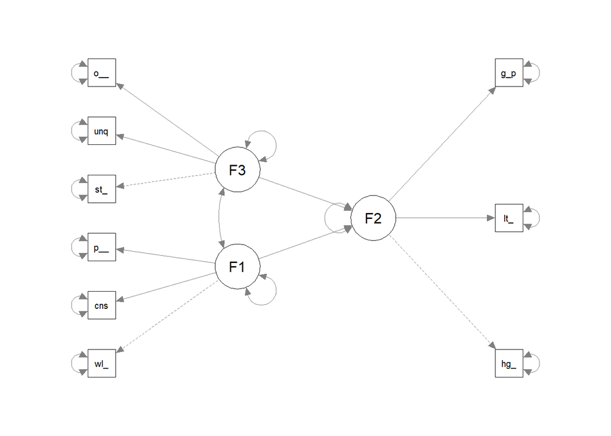

```r
modelo<-"F1 =~ well_made + consistent + poor_workman_r
         F2 =~ higher_price + lot_more + go_up
         F3 =~ stands_out + unique + one_of_a_kind
         F1 ~~ F3
         F2 ~ F1 + F3"
brand_rep_sem<-lavaan::cfa(model=modelo, data=scale(brand))
semPlot::semPaths(brand_rep_sem, rotation = 2)
```

- Observar as informações dos coeficientes (`est.std` e `pvalue`) das regressoes lineares (operador `~`)

```r
standardizedSolution(brand_rep_sem) %>%
  filter(op == "~")
```

```
##   lhs op rhs    est.std         se         z    pvalue    ci.lower
## 1  F2  ~  F1 0.06099283 0.04659486  1.309004 0.1905332 -0.03033141
## 2  F2  ~  F3 0.50333602 0.04146795 12.137953 0.0000000  0.42206033
##    ci.upper
## 1 0.1523171
## 2 0.5846117
```

Entre `F2` e `F3` há um bom ajuste, mas não entre `F2` e `F1`.

- Observar o ajuste da regressao `F2 ~ F1 + F3`. Para isso, veja o coeficiente R2 com a função `inspect()` da variável que tem como resposta a variável `F2`

```r
R2_F2 <- inspect(brand_rep_sem, 'r2')["F2"]
R2_F2
```

```
##        F2
## 0.2853633
```

Por isso é importante explorar as relações existentes entre os fatores em Modelos Equacionais Estruturais com validade de critério (ver os coeficientes das regressões, p.ex.).

- Explorando os escores dos fatores

Os escores individuais dos respondentes para os fatores latentes podem ser uteis para realizar segmentação de consumidores, via técnicas de clustering, análise de redes, etc.

A. Extraindo os escores dos fatores em um data.frame:

```r
brand_rep_scores <- as.data.frame(predict(brand_rep_sem))
head(brand_rep_scores)
```

```
##           F1         F2          F3
## 1 -0.5559469 -1.1100498 -0.87470851
## 2 -0.4072302  0.7227368 -0.75740172
## 3 -0.5222490 -0.5563355 -0.05579173
## 4  2.9222907  1.1390371  2.54058331
## 5 -0.5559469 -1.1100498 -0.87470851
## 6 -0.5383557  0.8162044 -0.78905605
```

B. Estatistica descritiva dos escores:

```r
describe(brand_rep_scores)
```

```
##    vars   n mean   sd median trimmed  mad   min  max range  skew kurtosis
## F1    1 559    0 0.88  -0.49   -0.19 0.09 -0.56 4.01  4.56  2.31     6.18
## F2    2 559    0 0.69   0.00    0.01 0.86 -1.11 1.15  2.26 -0.06    -1.18
## F3    3 559    0 0.95  -0.05   -0.15 1.15 -0.87 2.57  3.44  1.09     0.35
##      se
## F1 0.04
## F2 0.03
## F3 0.04
```

C. Histogramas de cada fator

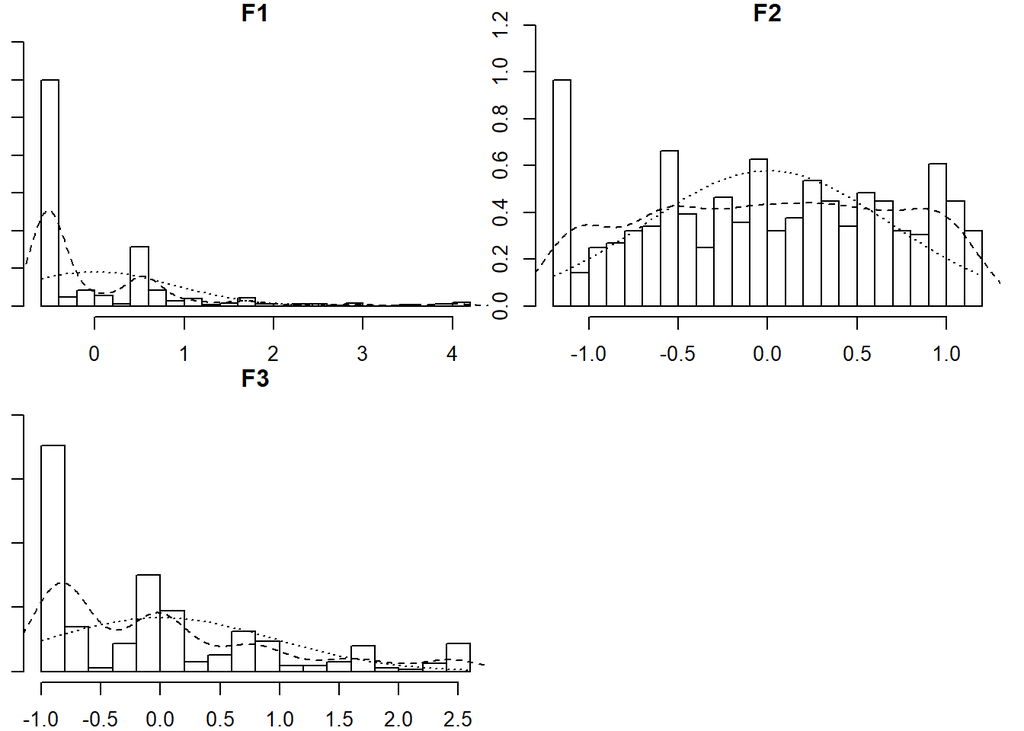

```r
multi.hist(brand_rep_scores)
```

D, Segue a normalidade?

```r
purrr::map(brand_rep_scores, shapiro.test)
```

```
## $F1
##
##  Shapiro-Wilk normality test
##
## data:  .x[[i]]
## W = 0.66884, p-value < 2.2e-16
##
##
## $F2
##
##  Shapiro-Wilk normality test
##
## data:  .x[[i]]
## W = 0.94861, p-value = 5.092e-13
##
##
## $F3
##
##  Shapiro-Wilk normality test
##
## data:  .x[[i]]
## W = 0.83278, p-value < 2.2e-16
```

Como não seguem a normalidade, isso pode ser um indicio de agrupamentos de consumidores.

### B. Concorrente

A validade concorrente é útil para ver se uma variavel latente do nosso constructo é relacionada ao mesmo tempo com algum resultado medido/obtido. No exemplo de `brand` podemos incluir uma variavel resultado: `spend`, que seria o gasto com o produto. Será que respondentes que apresentam maiores notas tendem a gastar mais nas lojas (clientes + felizes = consumidores que + gastam)?

```r
brand_spend<-scale(read.csv("brand_spend.csv"))

# Correlacionar F1, F2 e F3 com spend_f (spend na forma latente)
brand_model <- 'F1 =~ well_made + consistent + poor_workman_r
                    F2 =~ higher_price + lot_more + go_up
                    F3 =~ stands_out + unique
                    spend_latente =~ spend
                    spend_latente ~~ F1 + F2 + F3'

brand_spend_cv <- sem(data = brand_spend, model = brand_model)
```

Mostrando os coeficientes:

```r
standardizedSolution(brand_spend_cv) %>% filter(rhs == "spend_latente")
```

```
##             lhs op           rhs   est.std         se        z pvalue
## 1            F1 ~~ spend_latente 0.4188200 0.03650946 11.47155      0
## 2            F2 ~~ spend_latente 0.4544334 0.03649017 12.45358      0
## 3            F3 ~~ spend_latente 0.4360441 0.03504776 12.44142      0
## 4 spend_latente ~~ spend_latente 1.0000000 0.00000000       NA     NA
##    ci.lower  ci.upper
## 1 0.3472628 0.4903772
## 2 0.3829139 0.5259528
## 3 0.3673517 0.5047364
## 4 1.0000000 1.0000000
```

Cada variavel latente se correlaciona positivamente e significativamente com `spend_latente`

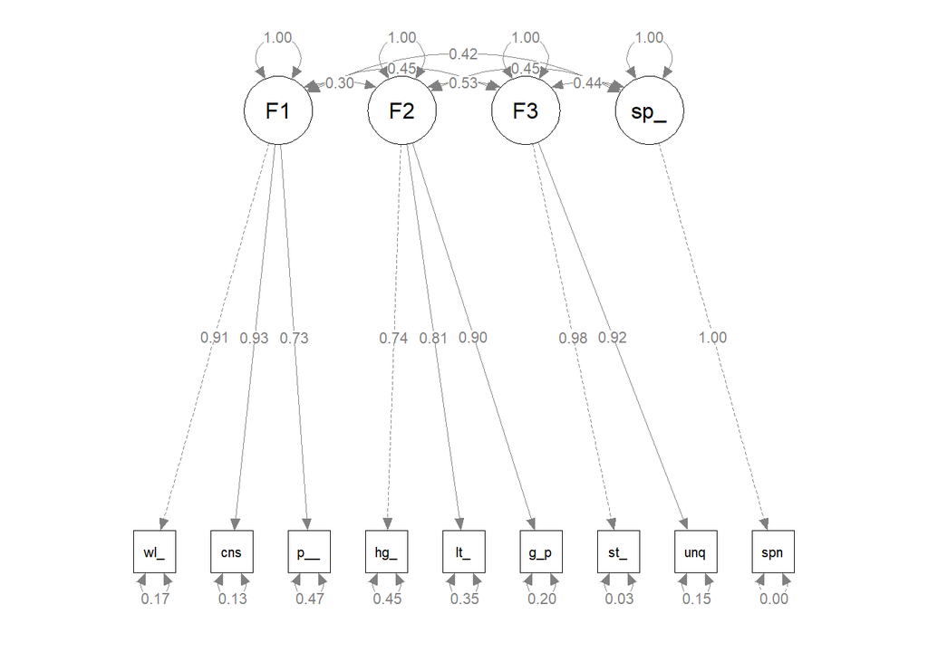

```r
# Plot the model with standardized estimate labels
semPaths(brand_spend_cv, whatLabels = "est.std", edge.label.cex = .8)
```

O gráfico é util para entender as relações. Variaveis observadas estao em quadrados e as latentes em circulos.